# Final Project

Hoin Lee & Changbin Kim

13/DEC/2022

### Setting

```r
# load all packages here: `mosaic`, `tidyverse`, `lubridate`, and all others used
library(tidyverse)
library(lubridate)
library(ggplot2)
library(dplyr)
library(esquisse)
library(mosaic)
library(mosaicData)
library(dcData)
```

```r
primary <- Provisional_COVID_19_Deaths_by_Sex_and_Age
death <- read_csv("United_States_COVID-19_Cases_and_Deaths_by_State_over_Time_-_ARCHIVED.csv")
condition <- Conditions_Contributing_to_COVID_19_Deaths_by_State_and_Age_Provisional_2020_2022
population <- poppulation_by_state
```

### Guiding Question

It’s been several years since the pandemic hit the world. What kind of groups in US were impacted most from Covid-19?

### Inspecting Data

```r
head(primary)
```

| Data As Of | Start Date | End Date | Group | Year | Month | State | Sex | Age Group | COVID-19 Deaths | Total Deaths | Pneumonia Deaths | Pneumonia and COVID-19 Deaths | Influenza Deaths | Pneumonia, Influenza, or COVID-19 Deaths | Footnote |
| --- | --- | --- | --- | --- | --- | --- | --- | --- | --- | --- | --- | --- | --- | --- | --- |
| 11/16/2022 | 01/01/2020 | 11/12/2022 | By Total | NA | NA | United States | All Sexes | All Ages | 1069807 | 9579442 | 991029 | 541427 | 12744 | 1530307 | NA |
| 11/16/2022 | 01/01/2020 | 11/12/2022 | By Total | NA | NA | United States | All Sexes | Under 1 year | 381 | 55597 | 745 | 63 | 44 | 1105 | NA |
| 11/16/2022 | 01/01/2020 | 11/12/2022 | By Total | NA | NA | United States | All Sexes | 0-17 years | 1360 | 98848 | 2060 | 347 | 273 | 3332 | NA |
| 11/16/2022 | 01/01/2020 | 11/12/2022 | By Total | NA | NA | United States | All Sexes | 1-4 years | 207 | 10612 | 439 | 48 | 89 | 683 | NA |
| 11/16/2022 | 01/01/2020 | 11/12/2022 | By Total | NA | NA | United States | All Sexes | 5-14 years | 426 | 16602 | 574 | 123 | 112 | 982 | NA |
| 11/16/2022 | 01/01/2020 | 11/12/2022 | By Total | NA | NA | United States | All Sexes | 15-24 years | 2848 | 102974 | 2642 | 1217 | 122 | 4386 | NA |

```r
str(primary)
```

```
spec_tbl_df [107,406 × 16] (S3: spec_tbl_df/tbl_df/tbl/data.frame)
 $ Data As Of                              : chr [1:107406] "11/16/2022" "11/16/2022" "11/16/2022" "11/16/2022" ...
 $ Start Date                              : chr [1:107406] "01/01/2020" "01/01/2020" "01/01/2020" "01/01/2020" ...
 $ End Date                                : chr [1:107406] "11/12/2022" "11/12/2022" "11/12/2022" "11/12/2022" ...
 $ Group                                   : chr [1:107406] "By Total" "By Total" "By Total" "By Total" ...
 $ Year                                    : num [1:107406] NA NA NA NA NA NA NA NA NA NA ...
 $ Month                                   : num [1:107406] NA NA NA NA NA NA NA NA NA NA ...
 $ State                                   : chr [1:107406] "United States" "United States" "United States" "United States" ...
 $ Sex                                     : chr [1:107406] "All Sexes" "All Sexes" "All Sexes" "All Sexes" ...
 $ Age Group                               : chr [1:107406] "All Ages" "Under 1 year" "0-17 years" "1-4 years" ...
 $ COVID-19 Deaths                         : num [1:107406] 1069807 381 1360 207 426 ...
 $ Total Deaths                            : num [1:107406] 9579442 55597 98848 10612 16602 ...
 $ Pneumonia Deaths                        : num [1:107406] 991029 745 2060 439 574 ...
 $ Pneumonia and COVID-19 Deaths           : num [1:107406] 541427 63 347 48 123 ...
 $ Influenza Deaths                        : num [1:107406] 12744 44 273 89 112 ...
 $ Pneumonia, Influenza, or COVID-19 Deaths: num [1:107406] 1530307 1105 3332 683 982 ...
 $ Footnote                                : chr [1:107406] NA NA NA NA ...
 - attr(*, "spec")=
  .. cols(
  ..   `Data As Of` = col_character(),
  ..   `Start Date` = col_character(),
  ..   `End Date` = col_character(),
  ..   Group = col_character(),
  ..   Year = col_double(),
  ..   Month = col_double(),
  ..   State = col_character(),
  ..   Sex = col_character(),
  ..   `Age Group` = col_character(),
  ..   `COVID-19 Deaths` = col_double(),
  ..   `Total Deaths` = col_double(),
  ..   `Pneumonia Deaths` = col_double(),
  ..   `Pneumonia and COVID-19 Deaths` = col_double(),
  ..   `Influenza Deaths` = col_double(),
  ..   `Pneumonia, Influenza, or COVID-19 Deaths` = col_double(),
  ..   Footnote = col_character()
  .. )
 - attr(*, "problems")=<externalptr>
```

The data provides the number of death by week-ending date and state. The number of deaths reported in this table is the total number of deaths received and coded as of the date of analysis.

Starting from January 2022, there has been a huge inflated number of deaths from Covid-19 in the US. As a result, the number of deaths in the US has also increased. When we are investigating whether the Covid-patients are decreasing or increasing, we need to watch out for the outliers in the dataset, where there has been a sudden increasing rate of deaths.

```r
head(death)
```

| submission_date | state | tot_cases | conf_cases | prob_cases | new_case | pnew_case | tot_death | conf_death | prob_death | new_death | pnew_death | created_at | consent_cases | consent_deaths |
| --- | --- | --- | --- | --- | --- | --- | --- | --- | --- | --- | --- | --- | --- | --- |
| 03/11/2021 | KS | 297229 | 241035 | 56194 | 0 | 0 | 4851 | NA | NA | 0 | 0 | 03/12/2021 03:20:13 PM | Agree | N/A |
| 12/01/2021 | ND | 163565 | 135705 | 27860 | 589 | 220 | 1907 | NA | NA | 9 | 0 | 12/02/2021 02:35:20 PM | Agree | Not agree |
| 01/02/2022 | AS | 11 | NA | NA | 0 | 0 | 0 | NA | NA | 0 | 0 | 01/03/2022 03:18:16 PM | NA | NA |
| 11/22/2021 | AL | 841461 | 620483 | 220978 | 703 | 357 | 16377 | 12727 | 3650 | 7 | 3 | 11/22/2021 12:00:00 AM | Agree | Agree |
| 05/30/2022 | AK | 251425 | NA | NA | 0 | 0 | 1252 | NA | NA | 0 | 0 | 05/31/2022 01:20:20 PM | N/A | N/A |
| 05/17/2020 | RMI | 0 | 0 | 0 | 0 | 0 | 0 | 0 | 0 | 0 | 0 | 05/18/2020 04:01:54 PM | Agree | Agree |

```r
str(death)
```

```
spec_tbl_df [60,060 × 15] (S3: spec_tbl_df/tbl_df/tbl/data.frame)
 $ submission_date: chr [1:60060] "03/11/2021" "12/01/2021" "01/02/2022" "11/22/2021" ...
 $ state          : chr [1:60060] "KS" "ND" "AS" "AL" ...
 $ tot_cases      : num [1:60060] 297229 163565 11 841461 251425 ...
 $ conf_cases     : num [1:60060] 241035 135705 NA 620483 NA ...
 $ prob_cases     : num [1:60060] 56194 27860 NA 220978 NA ...
 $ new_case       : num [1:60060] 0 589 0 703 0 ...
 $ pnew_case      : num [1:60060] 0 220 0 357 0 0 NA 274 0 0 ...
 $ tot_death      : num [1:60060] 4851 1907 0 16377 1252 ...
 $ conf_death     : num [1:60060] NA NA NA 12727 NA ...
 $ prob_death     : num [1:60060] NA NA NA 3650 NA 0 NA 429 NA NA ...
 $ new_death      : num [1:60060] 0 9 0 7 0 0 0 8 0 6 ...
 $ pnew_death     : num [1:60060] 0 0 0 3 0 0 NA 3 0 0 ...
 $ created_at     : chr [1:60060] "03/12/2021 03:20:13 PM" "12/02/2021 02:35:20 PM" "01/03/2022 03:18:16 PM" "11/22/2021 12:00:00 AM" ...
 $ consent_cases  : chr [1:60060] "Agree" "Agree" NA "Agree" ...
 $ consent_deaths : chr [1:60060] "N/A" "Not agree" NA "Agree" ...
 - attr(*, "spec")=
  .. cols(
  ..   submission_date = col_character(),
  ..   state = col_character(),
  ..   tot_cases = col_double(),
  ..   conf_cases = col_double(),
  ..   prob_cases = col_double(),
  ..   new_case = col_double(),
  ..   pnew_case = col_double(),
  ..   tot_death = col_double(),
  ..   conf_death = col_double(),
  ..   prob_death = col_double(),
  ..   new_death = col_double(),
  ..   pnew_death = col_double(),
  ..   created_at = col_character(),
  ..   consent_cases = col_character(),
  ..   consent_deaths = col_character()
  .. )
 - attr(*, "problems")=<externalptr>
```

The data provides the number of cases and deaths by the state over time in the US. The dataset contains archived aggregate daily counts of COVID-19 cases and death by the state.

There is a US Jurisdiction(Puerto Rico) that is officially not a US state. In order to analyze, we need to eliminate the Jusrsdictions that are not US states.

```r
head(condition)
```

| Data As Of | Start Date | End Date | Group | Year | Month | State | Condition Group | Condition | ICD10_codes | Age Group | COVID-19 Deaths | Number of Mentions | Flag |
| --- | --- | --- | --- | --- | --- | --- | --- | --- | --- | --- | --- | --- | --- |
| 11/13/2022 | 01/01/2020 | 11/12/2022 | By Total | NA | NA | United States | Respiratory diseases | Influenza and pneumonia | J09-J18 | 0-24 | 1448 | 1513 | NA |
| 11/13/2022 | 01/01/2020 | 11/12/2022 | By Total | NA | NA | United States | Respiratory diseases | Influenza and pneumonia | J09-J18 | 25-34 | 5660 | 5874 | NA |
| 11/13/2022 | 01/01/2020 | 11/12/2022 | By Total | NA | NA | United States | Respiratory diseases | Influenza and pneumonia | J09-J18 | 35-44 | 14767 | 15375 | NA |
| 11/13/2022 | 01/01/2020 | 11/12/2022 | By Total | NA | NA | United States | Respiratory diseases | Influenza and pneumonia | J09-J18 | 45-54 | 36761 | 38195 | NA |
| 11/13/2022 | 01/01/2020 | 11/12/2022 | By Total | NA | NA | United States | Respiratory diseases | Influenza and pneumonia | J09-J18 | 55-64 | 80664 | 83580 | NA |
| 11/13/2022 | 01/01/2020 | 11/12/2022 | By Total | NA | NA | United States | Respiratory diseases | Influenza and pneumonia | J09-J18 | 65-74 | 124226 | 128067 | NA |

```r
str(condition)
```

```
spec_tbl_df [484,380 × 14] (S3: spec_tbl_df/tbl_df/tbl/data.frame)
 $ Data As Of        : chr [1:484380] "11/13/2022" "11/13/2022" "11/13/2022" "11/13/2022" ...
 $ Start Date        : chr [1:484380] "01/01/2020" "01/01/2020" "01/01/2020" "01/01/2020" ...
 $ End Date          : chr [1:484380] "11/12/2022" "11/12/2022" "11/12/2022" "11/12/2022" ...
 $ Group             : chr [1:484380] "By Total" "By Total" "By Total" "By Total" ...
 $ Year              : num [1:484380] NA NA NA NA NA NA NA NA NA NA ...
 $ Month             : num [1:484380] NA NA NA NA NA NA NA NA NA NA ...
 $ State             : chr [1:484380] "United States" "United States" "United States" "United States" ...
 $ Condition Group   : chr [1:484380] "Respiratory diseases" "Respiratory diseases" "Respiratory diseases" "Respiratory diseases" ...
 $ Condition         : chr [1:484380] "Influenza and pneumonia" "Influenza and pneumonia" "Influenza and pneumonia" "Influenza and pneumonia" ...
 $ ICD10_codes       : chr [1:484380] "J09-J18" "J09-J18" "J09-J18" "J09-J18" ...
 $ Age Group         : chr [1:484380] "0-24" "25-34" "35-44" "45-54" ...
 $ COVID-19 Deaths   : num [1:484380] 1448 5660 14767 36761 80664 ...
 $ Number of Mentions: num [1:484380] 1513 5874 15375 38195 83580 ...
 $ Flag              : chr [1:484380] NA NA NA NA ...
 - attr(*, "spec")=
  .. cols(
  ..   `Data As Of` = col_character(),
  ..   `Start Date` = col_character(),
  ..   `End Date` = col_character(),
  ..   Group = col_character(),
  ..   Year = col_double(),
  ..   Month = col_double(),
  ..   State = col_character(),
  ..   `Condition Group` = col_character(),
  ..   Condition = col_character(),
  ..   ICD10_codes = col_character(),
  ..   `Age Group` = col_character(),
  ..   `COVID-19 Deaths` = col_double(),
  ..   `Number of Mentions` = col_double(),
  ..   Flag = col_character()
  .. )
 - attr(*, "problems")=<externalptr>
```

This data set shows the health conditions and contributing causes of deaths involving COVID-19 by age group and occurrence.

```r
head(population)
```

| State | Total Resident Population | Resident Population Age 18 Years and Older |
| --- | --- | --- |
| United States | 331893745 | 258327312 |
| Northeast | 57159838 | 45423447 |
| Midwest | 68841444 | 53386872 |
| South | 127225329 | 98456894 |
| West | 78667134 | 61060099 |
| Alabama | 5039877 | 3917625 |

```r
str(population)
```

```
spec_tbl_df [56 × 3] (S3: spec_tbl_df/tbl_df/tbl/data.frame)
 $ State                                        : chr [1:56] "United States" "Northeast" "Midwest" "South" ...
 $ Total Resident
 Population                  : num [1:56] 3.32e+08 5.72e+07 6.88e+07 1.27e+08 7.87e+07 ...
 $ Resident Population Age 18
  Years and Older: num [1:56] 2.58e+08 4.54e+07 5.34e+07 9.85e+07 6.11e+07 ...
 - attr(*, "spec")=
  .. cols(
  ..   State = col_character(),
  ..   `Total Resident
  ..  Population` = col_number(),
  ..   `Resident Population Age 18
  ..   Years and Older` = col_number()
  .. )
 - attr(*, "problems")=<externalptr>
```

The data provides the total number of resident population by state.

### Clearing data

In order to get clear output, we removed all of each overlapped values and each data set’s outlier because there are some overlapped datas from in our data set and the outlier would lead to mess our output.

### 1. The number of COVID patient between 2020/01/01 and 2022/11/12

### Death by age

```r
Primary <-
  primary %>%
  filter(State != "United States")

Primary <-
  Primary %>%
  filter(State != "Puerto Rico")

Primarya <-
  Primary %>%
  filter(`End Date` == "11/12/2022")

Primarya <-
  Primarya %>%
  filter(`Start Date` == "01/01/2020")

PrimaryaR <-
  Primarya %>%
  group_by(Sex,`Age Group`) %>%
  summarise(total = sum(`COVID-19 Deaths`, na.rm = TRUE)) %>%
  filter(Sex %in% c('Male','Female')) %>%
  filter(`Age Group` %in% c("0-17 years", "18-29 years", "30-39 years", "40-49 years", "50-64 years", "65-74 years", "75-84 years", "85 years and over") )
PrimaryaR1 <-
  PrimaryaR %>%
  relocate(`Age Group`)

Death_by_Age <-
  PrimaryaR1 %>%
  pivot_wider(names_from = Sex, values_from = total) %>%
  mutate(total = Female + Male)

Death_by_Age
```

| Age Group | Female | Male | total |
| --- | --- | --- | --- |
| 0-17 years | 513 | 592 | 1105 |
| 18-29 years | 2523 | 4034 | 6557 |
| 30-39 years | 7272 | 11792 | 19064 |
| 40-49 years | 16684 | 28085 | 44769 |
| 50-64 years | 74193 | 121424 | 195617 |
| 65-74 years | 98748 | 144156 | 242904 |
| 75-84 years | 121812 | 155486 | 277298 |
| 85 years and over | 157850 | 124226 | 282076 |

Overlapping data: “United States, Puerto Rico, All sexes” and also the time period of start and end date are overlapped, so we filter the start date with “01/01/2020” and the end date with “11/12/2022”. About age group, there are also overlapped data of age interval, so we filter out the specific age interval: “0-17 years”, “18-29 years”, “30-39 years”, “40-49 years”, “50-64 years”, “65-74 years”, “75-84 years”, “85 years and over”.

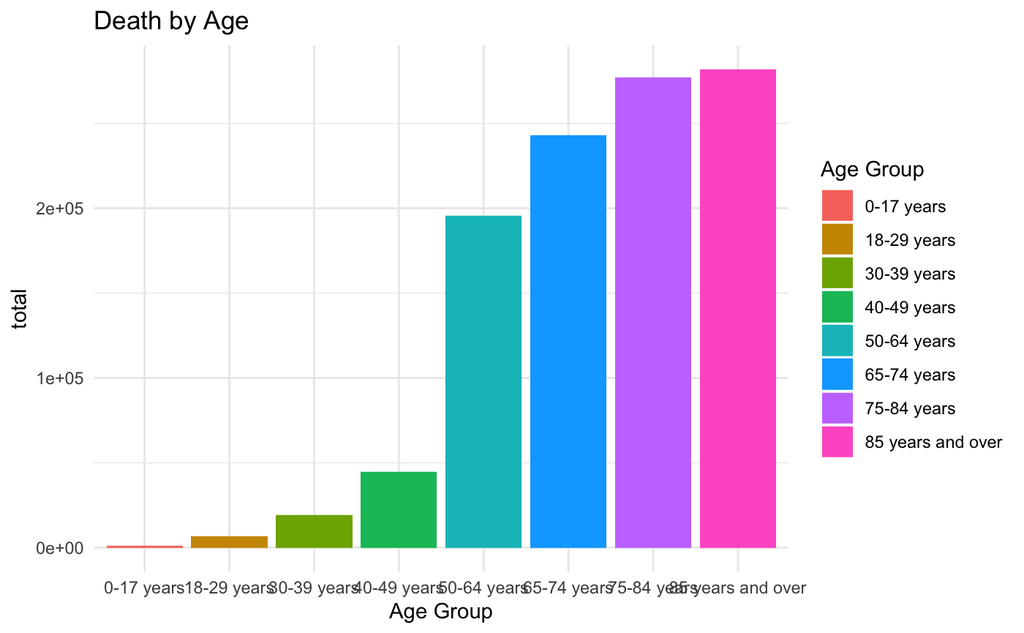

```r
ggplot(Death_by_Age) +
  aes(x = `Age Group`, y = total, fill = `Age Group`) +
  geom_col() +
  scale_fill_hue(direction = 1) +
  labs(title = "Death by Age") +
  theme_minimal()
```

The data shows that people who are over 50 years old have a high percentage of death from COVID-19. Overall, we were able to find out the elder people are more likely to die from COVID-19; especially those over 50 years old, and its number of counts is greatly increased.

### Death by sex

```r
Death_by_sex <-
  PrimaryaR1 %>%
  group_by(Sex) %>%
  summarise(Total = sum(total))

Death_by_sex
```

| Sex | Total |
| --- | --- |
| Female | 479595 |
| Male | 589795 |

```r
NA
```

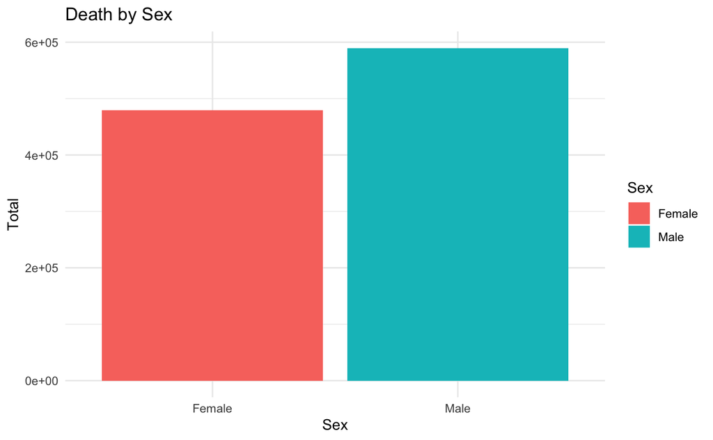

```r
ggplot(Death_by_sex) +
  aes(x = Sex, y = Total, fill = Sex) +
  geom_col() +
  scale_fill_hue(direction = 1) +
  labs(title = "Death by Sex") +
  theme_minimal()
```

According to the US census(“https://www.statista.com/statistics/737923/us-population-by-gender/#:~:text=Projection%20estimates%20calculated%20using%20the,US%20Census%20data%20for%202021.”), they calculated each gender’s population, and population ratio is about 49.5% male and 50.47 female. the number of males and females in the United States is most likely the same. However, the graph shows that a number of males had died than females. Based on this graph, we may conclude that COVID-19 lead male to die at a higher percentage compared to female.

### Death by state

```r
Primary3 <-
  Primary2 %>%
  group_by(`State`) %>%
  summarise(total = sum(`COVID-19 Deaths`, na.rm = TRUE)) %>%
  arrange(desc(total))

Primary3
```

| State | total |
| --- | --- |
| California | 101561 |
| Texas | 99555 |
| Florida | 76356 |
| Pennsylvania | 49408 |
| Ohio | 46306 |
| New York | 39029 |
| New York City | 36472 |
| Illinois | 36460 |
| Michigan | 34472 |
| Georgia | 34403 |

[output cut: 42 more lines]

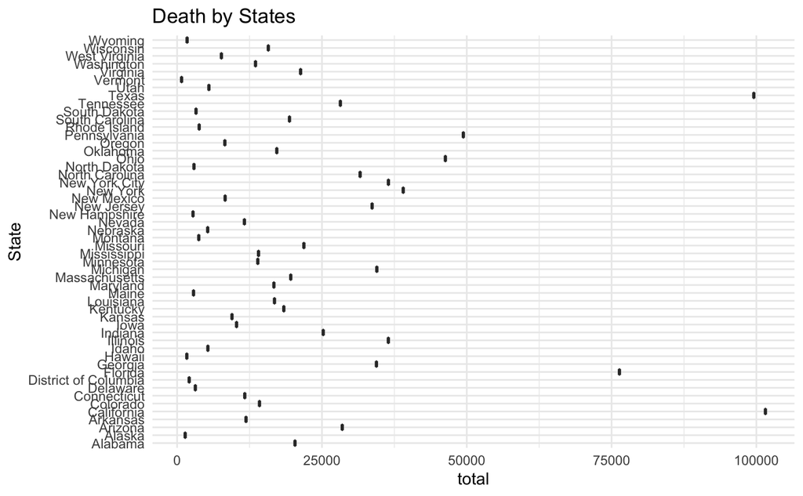

```r
ggplot(Primary3) +
  aes(x = total, y = State) +
  geom_boxplot(fill = "#112446") +
  labs(title = "Death by States") +
  theme_minimal()
```

Using the “arrange” function, we easily find out which state has the most number of death from COVID-19. Obviously, the population by the state would affect the number of death by state because the population by the state is mostly proportional to the number of death by the state. The data shows that the major states have a high number of deaths by COVID-19 considering their dense populations.

### 2. Number of deaths by each States.

### Geographically distribution

```
Mapping API still under development and may change in future releases.
Warning: 1 items were not translated
```

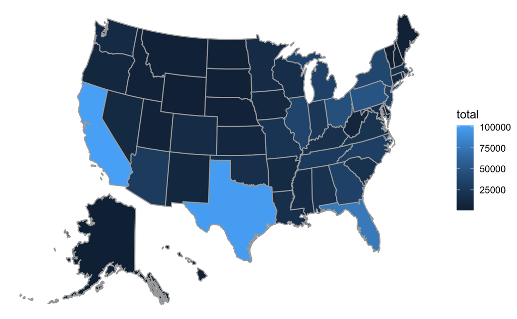

```r
mUSMap(Primary3, key="State", fill = "total")
```

### Deathratio by state

```r
DeathRatioState <-
  Primary3 %>%
  inner_join(pop, by = c("State" = "table with row headers in column A and column headers in rows 3 through 5. (leading dots indicate sub-parts)")) %>%
  arrange(desc(total))
DeathRatioState
```

| State | total | ...2 | ...3 | ...4 |
| --- | --- | --- | --- | --- |
| California | 101561 | 39,237,836 | 30,465,205 | NA |
| Texas | 99555 | 29,527,941 | 22,052,508 | NA |
| Florida | 76356 | 21,781,128 | 17,491,848 | NA |
| Pennsylvania | 49408 | 12,964,056 | 10,290,047 | NA |
| Ohio | 46306 | 11,780,017 | 9,174,388 | NA |
| New York | 39029 | 19,835,913 | 15,722,590 | NA |
| Illinois | 36460 | 12,671,469 | 9,868,245 | NA |
| Michigan | 34472 | 10,050,811 | 7,897,432 | NA |
| Georgia | 34403 | 10,799,566 | 8,275,264 | NA |
| New Jersey | 33657 | 9,267,130 | 7,244,002 | NA |

[output cut: 41 more lines]

### Geographically Distribution of Death Ratio by State

```
Mapping API still under development and may change in future releases.
```

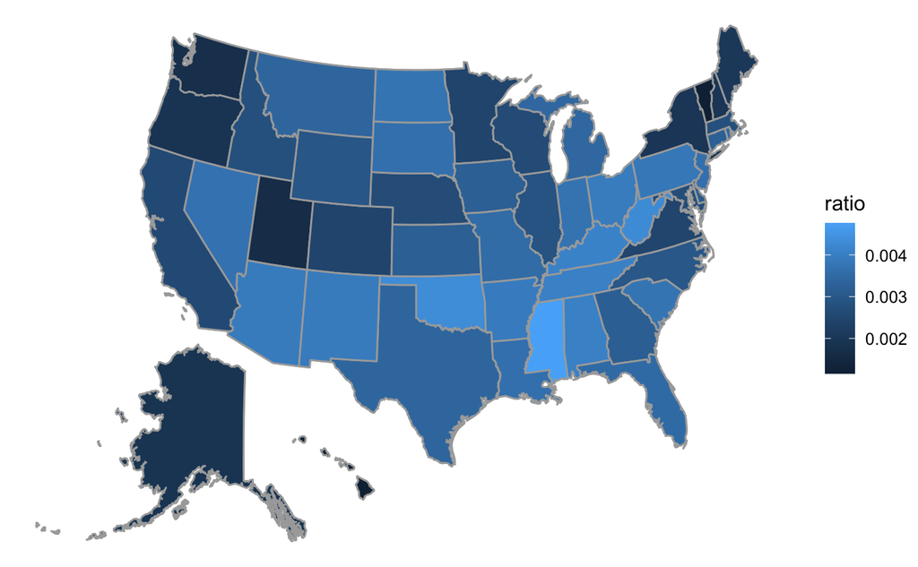

```r
DeathRatioState <-
  Primary3 %>%
  inner_join(population)
DeathRatioState1 <-
  DeathRatioState %>%
  mutate(ratio = total / `Total Resident
 Population`)

mUSMap(DeathRatioState1, key = "State", fill = "ratio")
```

```r
DeathRatioState1 %>%
  select('State', 'ratio') %>%
  arrange(desc(ratio))
```

| State | ratio |
| --- | --- |
| Mississippi | 0.004762090 |
| Oklahoma | 0.004314662 |
| West Virginia | 0.004283890 |
| Kentucky | 0.004083697 |
| Tennessee | 0.004039587 |
| Alabama | 0.004036606 |
| Ohio | 0.003930894 |
| Arkansas | 0.003929421 |
| Arizona | 0.003917367 |
| New Mexico | 0.003914216 |

[output cut: 41 more lines]

### Death by body condition

```r
condition1 <-
  condition %>%
  filter(`Age Group` == 'All Ages') %>%
  filter(State == 'United States') %>%
  filter(row_number() <= 23)
condition2 <-
  condition1 %>%
  group_by(`Condition`) %>%
  summarise(total = sum(`COVID-19 Deaths`, na.rm = TRUE))%>%
  arrange(desc(total))
condition2
```

| Condition | total |
| --- | --- |
| COVID-19 | 1068055 |
| Influenza and pneumonia | 506384 |
| All other conditions and causes (residual) | 436243 |
| Respiratory failure | 412035 |
| Hypertensive diseases | 197581 |
| Diabetes | 159237 |
| Cardiac arrest | 126622 |
| Renal failure | 120421 |
| Ischemic heart disease | 116619 |
| Sepsis | 109958 |

[output cut: 13 more lines]

```r
#filter(`Condition Group` != 'All other conditions and causes (residual)') %>%
#filter(`Condition Group` != 'Alzheimer disease') %>%
```

### Which conditions(age, sex, state, body’s condition, ratio) are mostly lead to die through COVID-19

```r
Primary1R
```

| Age Group | total |
| --- | --- |
| 0-17 years | 1282 |
| 18-29 years | 6653 |
| 30-39 years | 19086 |
| 40-49 years | 44784 |
| 50-64 years | 195617 |
| 65-74 years | 242904 |
| 75-84 years | 277298 |
| 85 years and over | 282076 |

```r
Primary2R
```

| Sex | total |
| --- | --- |
| Female | 479595 |
| Male | 589795 |

```r
Primary3
```

| State | total |
| --- | --- |
| California | 101561 |
| Texas | 99555 |
| Florida | 76356 |
| Pennsylvania | 49408 |
| Ohio | 46306 |
| New York | 39029 |
| New York City | 36472 |
| Illinois | 36460 |
| Michigan | 34472 |
| Georgia | 34403 |

[output cut: 42 more lines]

```r
condition2 %>%
  arrange(desc(total))
```

| Condition | total |
| --- | --- |
| COVID-19 | 1068055 |
| Influenza and pneumonia | 506384 |
| All other conditions and causes (residual) | 436243 |
| Respiratory failure | 412035 |
| Hypertensive diseases | 197581 |
| Diabetes | 159237 |
| Cardiac arrest | 126622 |
| Renal failure | 120421 |
| Ischemic heart disease | 116619 |
| Sepsis | 109958 |

[output cut: 13 more lines]

```r
DeathRatioState1 %>%
  select('State', 'ratio') %>%
  arrange(desc(ratio))
```

| State | ratio |
| --- | --- |
| Mississippi | 0.004762090 |
| Oklahoma | 0.004314662 |
| West Virginia | 0.004283890 |
| Kentucky | 0.004083697 |
| Tennessee | 0.004039587 |
| Alabama | 0.004036606 |
| Ohio | 0.003930894 |
| Arkansas | 0.003929421 |
| Arizona | 0.003917367 |
| New Mexico | 0.003914216 |

[output cut: 41 more lines]

```r
NA
```

### Conclusion

It is been several years since the pandemic hit the world. There were numerous casualties and infections around our life and the entire globe. From this motivation, Our research question is “What kind of groups in the US were impacted most by Covid-19?” According to these data outcomes, we are able to find out, in United states, the condition of ‘85 years and over’ or ‘male’,‘who has influenza and pneumonia’ or ‘who lives in Mississippi’ would have been mostly leading to death. Additionally, based on this evidence from the data sets, we are able to emphasize that COVID-19 is one of the greatest prevalent diseases in any disease that humanity has experienced. For now, we may feel COVID-19 is a common disease, such as influenza. Based from our research, we learned that we still need a steady concern about Covid-19.